# Exploration of California’s Contributions to 2016 Presidential Campaigns by Alf

I chose California since it is the most populous state in the United States of America (USA). It has the most Democratic Party delegates; it has the most Republican Party delegates. And come the general election, California has the most members in the electoral college. It is clearly a very important state in the USA.

I aim to explore California’s presidential campaign finance to get an idea of how the presidential candidates and their respective parties will fare in this important state on June 7 2016 when the last primaries, including California’s, are held in the USA.

# California Presidential Campaign Finance, dataframe capcf

# Data Description

```
## 'data.frame':    180478 obs. of  18 variables:
##  $ cmte_id          : Factor w/ 22 levels "C00458844","C00500587",..: 7 7 7 7 7 7 7 7 7 1 ...
##  $ cand_id          : Factor w/ 22 levels "P00003392","P20002721",..: 11 11 11 11 11 11 11 11 11 10 ...
##  $ cand_nm          : Factor w/ 22 levels "Bush, Jeb","Carson, Benjamin S.",..: 17 17 17 17 17 17 17 17 17 16 ...
##  $ contbr_nm        : Factor w/ 53137 levels "A DOSS, CANDALON",..: 11630 17344 17458 17769 34345 34388 34523 23164 23246 42658 ...
##  $ contbr_city      : Factor w/ 1282 levels "","29 PALMS",..: 990 45 219 986 775 135 44 986 1028 642 ...
##  $ contbr_st        : Factor w/ 1 level "CA": 1 1 1 1 1 1 1 1 1 1 ...
##  $ contbr_zip       : Factor w/ 45475 levels "","0","00EC1",..: 30379 41731 11754 15055 34361 11139 8138 14713 38434 4990 ...
##  $ contbr_employer  : Factor w/ 19333 levels "","'K' LINE AMERICA",..: 398 11860 11860 15042 11860 11860 11860 18015 11860 5649 ...
##  $ contbr_occupation: Factor w/ 8957 levels "","'NOT EMPLOYED'",..: 7686 5220 5220 7139 5220 5220 6766 4950 5220 6519 ...
##  $ contb_receipt_amt: num  50 100 1000 5 196 ...
##  $ contb_receipt_dt : Factor w/ 397 levels "01-APR-15","01-AUG-15",..: 137 250 250 250 277 250 250 76 76 313 ...
##  $ receipt_desc     : Factor w/ 51 levels "","* REATTRIBUTED FROM ERIC UHRANE",..: 1 1 1 1 1 1 1 1 1 1 ...
##  $ memo_cd          : Factor w/ 2 levels "","X": 1 1 1 1 1 1 1 1 1 1 ...
##  $ memo_text        : Factor w/ 176 levels "","$1,500 REFUNDED ON 2/3/16.",..: 7 7 7 7 1 7 7 7 7 1 ...
##  $ form_tp          : Factor w/ 3 levels "SA17A","SA18",..: 1 1 1 1 1 1 1 1 1 1 ...
##  $ file_num         : int  1029414 1029414 1029414 1029414 1029414 1029414 1029414 1029414 1029414 1029436 ...
##  $ tran_id          : Factor w/ 179350 levels "A000771210424405B8CF",..: 112662 113607 113531 113584 115809 113588 113586 112271 112282 86613 ...
##  $ election_tp      : Factor w/ 5 levels "","G2016","P2016",..: 3 3 3 3 3 3 3 3 3 3 ...
```

```
##       cmte_id           cand_id                           cand_nm
##  C00577130:72179   P60007168:72179   Sanders, Bernard         :72179
##  C00575795:42063   P00003392:42063   Clinton, Hillary Rodham  :42063
##  C00574624:21645   P60006111:21645   Cruz, Rafael Edward 'Ted':21645
##  C00573519:21045   P60005915:21045   Carson, Benjamin S.      :21045
##  C00458844: 7994   P60006723: 7994   Rubio, Marco             : 7994
##  C00577312: 4426   P60007242: 4426   Fiorina, Carly           : 4426
##  (Other)  :11126   (Other)  :11126   (Other)                  :11126
##               contbr_nm             contbr_city     contbr_st
##  BHOOMA, PRAMOD MR.:   171   LOS ANGELES  : 11915   CA:180478
##  IMEOKPARIA, OSI   :   125   SAN FRANCISCO: 11223
##  MERRELL, KATHERINE:   109   SAN DIEGO    :  6274
##  BATTS, ERIC       :   106   SAN JOSE     :  4319
##  TRAWICK, MARGARET :   101   OAKLAND      :  3518
##  HABEL, DANIEL     :    87   BERKELEY     :  2873
##  (Other)           :179779   (Other)      :140356
##      contbr_zip          contbr_employer
##  951241559:   171   RETIRED      :30414
##  943061338:   125   NOT EMPLOYED :20567
##  954039414:   109   SELF-EMPLOYED:10632
##  941311708:   106   SELF         : 9972
##  945204337:   101   N/A          : 9039
##  920274404:    89   NONE         : 6090
##  (Other)  :179777   (Other)      :93764
##                               contbr_occupation  contb_receipt_amt
##  RETIRED                               : 36006   Min.   :-10000.0
##  NOT EMPLOYED                          : 20446   1st Qu.:    25.0
##  ATTORNEY                              :  4667   Median :    50.0
##  HOMEMAKER                             :  3441   Mean   :   262.4
##  TEACHER                               :  2936   3rd Qu.:   100.0
##  INFORMATION REQUESTED PER BEST EFFORTS:  2839   Max.   : 10800.0
##  (Other)                               :110143
##   contb_receipt_dt                      receipt_desc    memo_cd
##  31-DEC-15:  4562                             :177128    :175097
##  29-JAN-16:  4381   Refund                    :  1041   X:  5381
##  30-SEP-15:  3372   REDESIGNATION TO GENERAL  :   621
##  31-JAN-16:  2773   REDESIGNATION FROM PRIMARY:   618
##  28-JAN-16:  2770   REATTRIBUTION FROM SPOUSE :   218
##  30-JAN-16:  2563   REATTRIBUTION TO SPOUSE   :   218
##  (Other)  :160057   (Other)                   :   634
##                                memo_text       form_tp
##                                     :108941   SA17A:176327
##  * EARMARKED CONTRIBUTION: SEE BELOW: 65441   SA18 :  3110
##  * HILLARY VICTORY FUND             :  2844   SB28A:  1041
##  REDESIGNATION TO GENERAL           :   621
##  REDESIGNATION FROM PRIMARY         :   618
##  EARMARKED FROM MAKE DC LISTEN      :   517
##  (Other)                            :  1496
##     file_num              tran_id       election_tp
##  Min.   :1003942   SA17.300674:     3        :   101
##  1st Qu.:1035757   SA17.365962:     3   G2016:  1995
##  Median :1046975   SA17.467606:     3   P2016:178374
##  Mean   :1042581   SA17.478662:     3   P2018:     1
##  3rd Qu.:1051531   SA17.774344:     3   P2020:     7
##  Max.   :1051624   SA17.832234:     3
##                    (Other)    :180460
```

```
##  [1] "Bush, Jeb"                 "Carson, Benjamin S."
##  [3] "Christie, Christopher J."  "Clinton, Hillary Rodham"
##  [5] "Cruz, Rafael Edward 'Ted'" "Fiorina, Carly"
##  [7] "Graham, Lindsey O."        "Huckabee, Mike"
##  [9] "Jindal, Bobby"             "Kasich, John R."
## [11] "Lessig, Lawrence"          "O'Malley, Martin Joseph"
## [13] "Pataki, George E."         "Paul, Rand"
## [15] "Perry, James R. (Rick)"    "Rubio, Marco"
## [17] "Sanders, Bernard"          "Santorum, Richard J."
## [19] "Stein, Jill"               "Trump, Donald J."
## [21] "Walker, Scott"             "Webb, James Henry Jr."
```

### Count of Contributions to Candidates

```
##
##          Sanders, Bernard   Clinton, Hillary Rodham
##                     72179                     42063
## Cruz, Rafael Edward 'Ted'       Carson, Benjamin S.
##                     21645                     21045
##              Rubio, Marco            Fiorina, Carly
##                      7994                      4426
##                Paul, Rand                 Bush, Jeb
##                      4117                      2762
##           Kasich, John R.             Walker, Scott
##                       701                       670
##          Trump, Donald J.            Huckabee, Mike
##                       590                       447
##   O'Malley, Martin Joseph          Lessig, Lawrence
##                       383                       372
##        Graham, Lindsey O.  Christie, Christopher J.
##                       331                       316
##    Perry, James R. (Rick)     Webb, James Henry Jr.
##                       116                       106
##               Stein, Jill      Santorum, Richard J.
##                        85                        79
##             Jindal, Bobby         Pataki, George E.
##                        31                        20
```

Most contributions are to Sanders, Clinton, Cruz, and Carson. The top cities where contributions came from are Los Angeles and San Francisco. The mean contribution amount (contb_receipt_amt) is 262.4 and the median is 50. The minimum contribution is a negative amount, possibly a refund. The maximum contribution is 10800, definitely an outlier.

# Univariate Plots Section

### Add candidates’ party affiliations and gender of contributors

```
##                   cand_names cand_lastnm cand_party
## 1           Sanders, Bernard     Sanders   Democrat
## 2               Rubio, Marco       Rubio Republican
## 3   Christie, Christopher J.    Christie Republican
## 4                  Bush, Jeb        Bush Republican
## 5        Carson, Benjamin S.      Carson Republican
## 6    Clinton, Hillary Rodham     Clinton   Democrat
## 7            Kasich, John R.      Kasich Republican
## 8           Trump, Donald J.       Trump Republican
## 9             Fiorina, Carly     Fiorina Republican
## 10 Cruz, Rafael Edward 'Ted'        Cruz Republican
## 11                Paul, Rand        Paul Republican
## 12      Santorum, Richard J.    Santorum Republican
## 13             Jindal, Bobby      Jindal Republican
## 14               Stein, Jill       Stein      Green
## 15            Huckabee, Mike    Huckabee Republican
## 16          Lessig, Lawrence      Lessig   Democrat
## 17     Webb, James Henry Jr.        Webb   Democrat
## 18         Pataki, George E.      Pataki Republican
## 19   O'Malley, Martin Joseph     Omalley   Democrat
## 20        Graham, Lindsey O.      Graham Republican
## 21    Perry, James R. (Rick)       Perry Republican
## 22             Walker, Scott      Walker Republican
```

### Add column cand_party (candidates’ parties) to dataframe

```
##
##   Democrat      Green Republican
##     115103         85      65290
```

```
##
##     Bush   Carson Christie  Clinton     Cruz  Fiorina   Graham Huckabee
##     2762    21045      316    42063    21645     4426      331      447
##   Jindal   Kasich   Lessig  Omalley   Pataki     Paul    Perry    Rubio
##       31      701      372      383       20     4117      116     7994
##  Sanders Santorum    Stein    Trump   Walker     Webb
##    72179       79       85      590      670      106
```

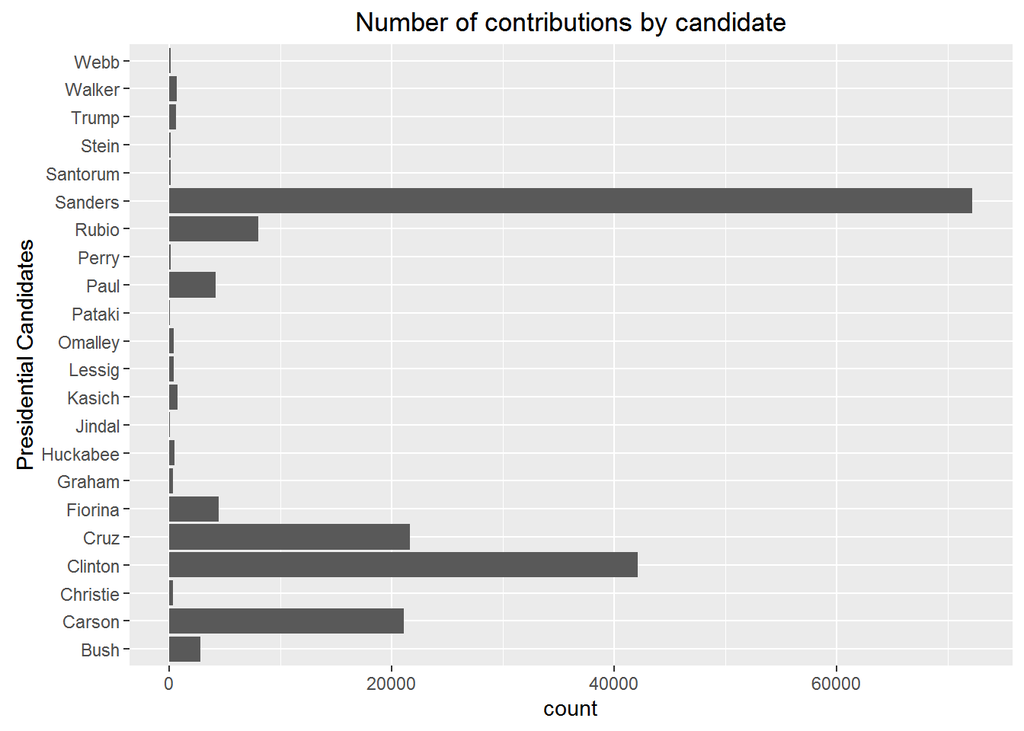

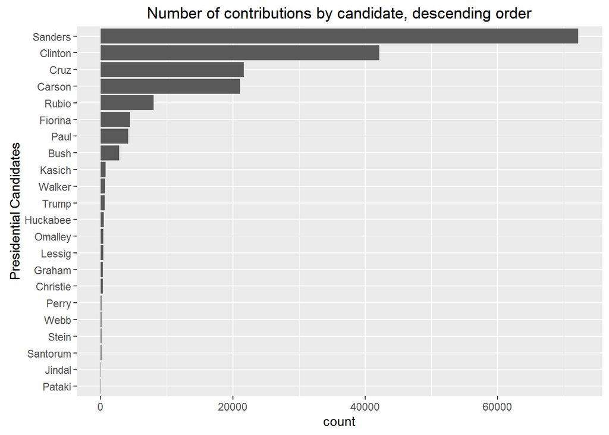

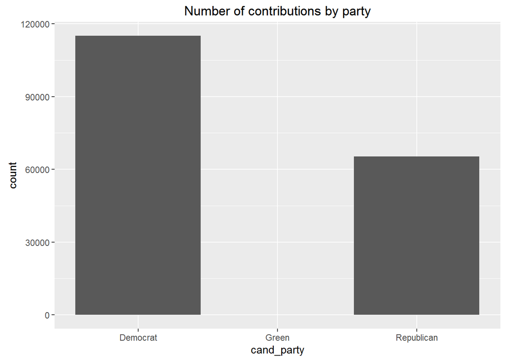

### Add a new column gender to capcf dataframe

The process of adding gender to each contributor involves extracting the first names of contributors, detecting the gender based on first names using the package gender from https://cran.r-project.org/web/packages/gender/index.html. The head and tail of first names are below.

```
##  [1] KIRA    STEVE   ALBERT  RICHARD JOY     STEPHEN STEVEN  SEAN
##  [9] CAROL   CARLEEN PETER   PETER   GEORGE  GEORGE  GEORGE
## 6755 Levels:  A A. A.H. A.J. AAKASH AAMIR AARAN AARON AARTHI ... ZVIA
```

```
##  [1] CAROL       CHRISTOPHER JOHN        RONALD      REGGIE
##  [6] EILEEN      SAM         JACK        ROSEMARY    WILLIAM
## [11] DAN         DENISE      MELVIN      DAWAYNE     ELWOOD
## 6755 Levels:  A A. A.H. A.J. AAKASH AAMIR AARAN AARON AARTHI ... ZVIA
```

I used help to get information on gender library: `?gender` I first ran the gender package on my name.

```
gender("alf", method="ssa", years=c(1932,2012))$gender
```

I noticed that the gender function is very slow. It took nearly a second to run the code above. It took nearly 12 minutes to run the gender function on 1000 first names.

I wrote the ApplyGender function so that I can run the function remotely every 8 hours.

I continued to clean up the gender using the prefix, i.e., if the contributor used a prefix. If contributor’s name contains a MR, MRS, or MS, I changed *unknown* to appropriate gender. After I invoked the last of the ApplyGender, dataframe had 5712 *unknown*s in the *gender* column. After more clean up, the last count of gender types is below.

```
##
##  female    male unknown
##   79023   96445    5010
```

```
##
##     female       male    unknown
## 0.43785392 0.53438646 0.02775962
```

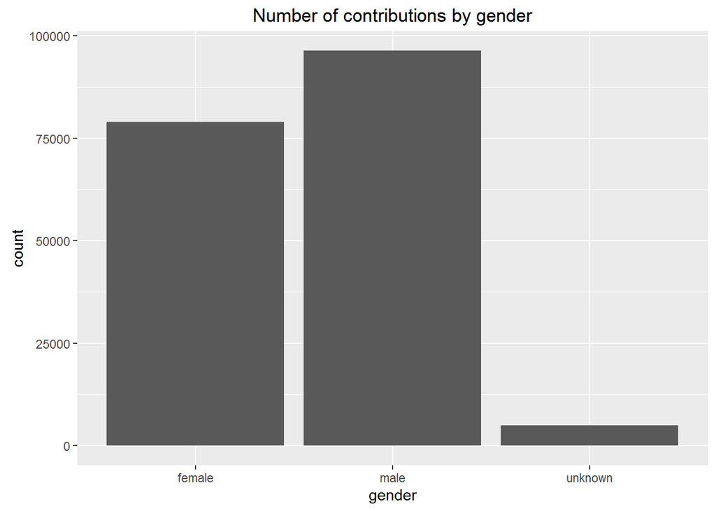

### Plots of contributions by gender faceted by candidate names

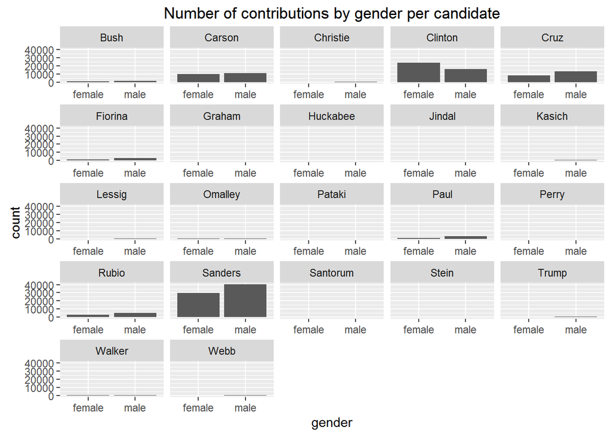

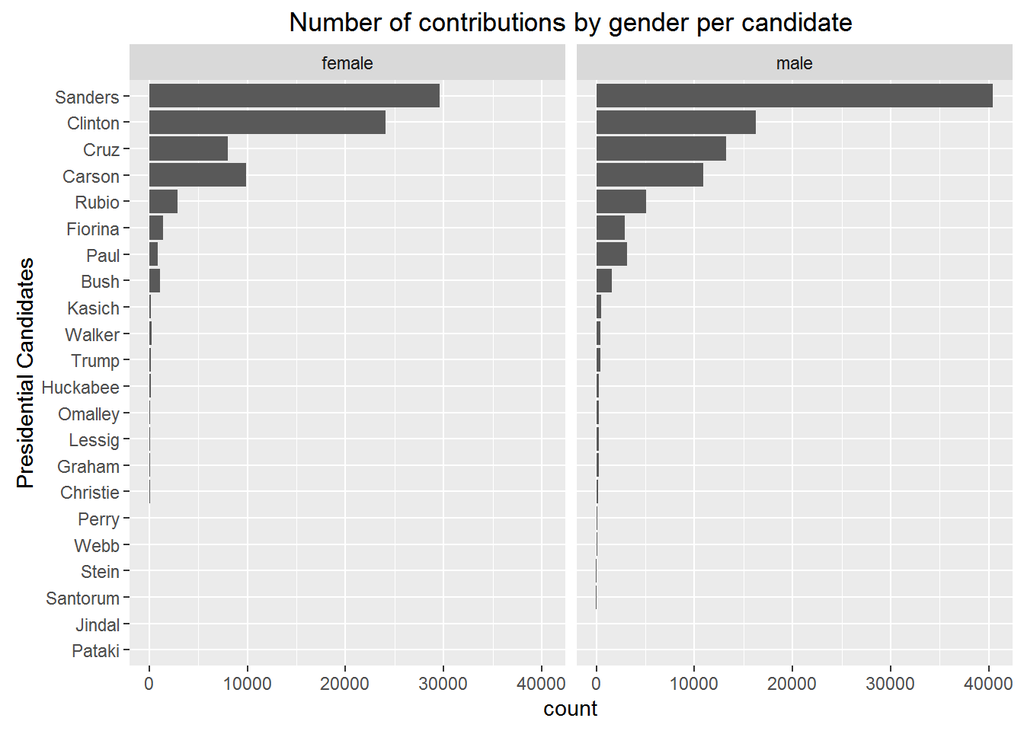

```
## capcf$gender: female
##     Bush   Carson Christie  Clinton     Cruz  Fiorina   Graham Huckabee
##     1079     9876      111    24075     8036     1400       82      159
##   Jindal   Kasich   Lessig  Omalley   Pataki     Paul    Perry    Rubio
##       12      152       70       93       10      892       38     2873
##  Sanders Santorum    Stein    Trump   Walker     Webb
##    29625       32       27      153      215       13
## --------------------------------------------------------
## capcf$gender: male
##     Bush   Carson Christie  Clinton     Cruz  Fiorina   Graham Huckabee
##     1613    10903      196    16285    13194     2931      228      276
##   Jindal   Kasich   Lessig  Omalley   Pataki     Paul    Perry    Rubio
##       18      527      289      275       10     3132       75     5052
##  Sanders Santorum    Stein    Trump   Walker     Webb
##    40398       47       58      421      427       90
## --------------------------------------------------------
## capcf$gender: unknown
##     Bush   Carson Christie  Clinton     Cruz  Fiorina   Graham Huckabee
##       70      266        9     1703      415       95       21       12
##   Jindal   Kasich   Lessig  Omalley   Pataki     Paul    Perry    Rubio
##        1       22       13       15        0       93        3       69
##  Sanders Santorum    Stein    Trump   Walker     Webb
##     2156        0        0       16       28        3
```

I temporarily took out the *unknown* *gender* from 2 plots above. The contributions from *unknown* gender seemed negligible compared to the number of contributions from females and males. It is however noteworthy that the *unknown*s mostly donated to Clinton’s and Sanders’ campaigns. These might be donors with first names that might be deemed as foreign by the *gender* package using the *ssa* method. It might be some sort of demographics.

Only Hillary clinton proportionally has more contributions from females. Even Carly Fiorina received more contributions from males than from females. But Bernard Sanders still received more contributions from females than any other candidate. Not only did Sanders receive the most contributions from females, but also the most from males.

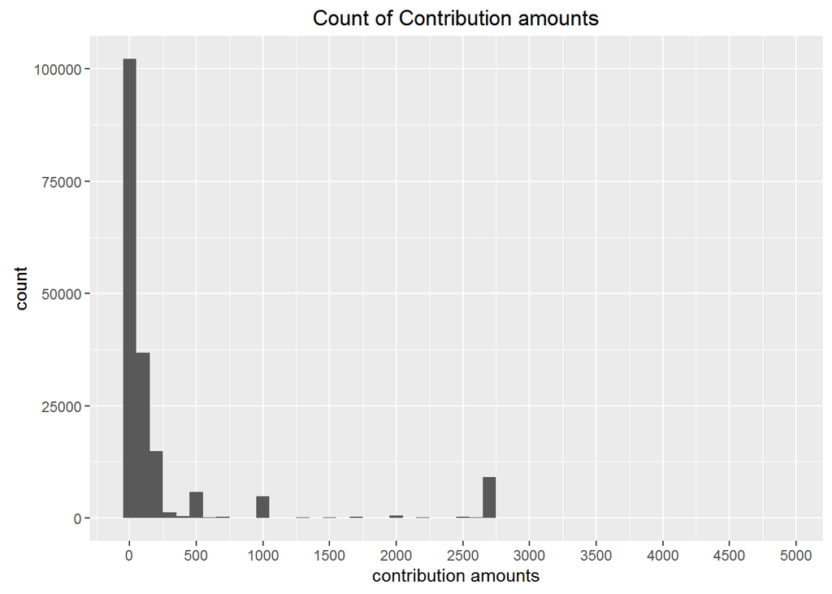

Most of the contributions are at or below 250. There are other spikes around 500, 1000, and strangely at 2750.

The result below shows top 10 contribution amounts which correspond to the spikes on the plot above. Contributions of $50, $100, and $25 are top 3 donation amounts, followed by $10 and $250 amounts. I noticed that the amount $2700 follows closely in the top sixth which corresponds to the last spike in the plot above.

```
##
##    50   100    25    10   250  2700    35   500     5  1000
## 28410 27627 25298 16290 10781  9032  6994  5644  5306  4759
```

### Top 20 occupations with most number of contributions

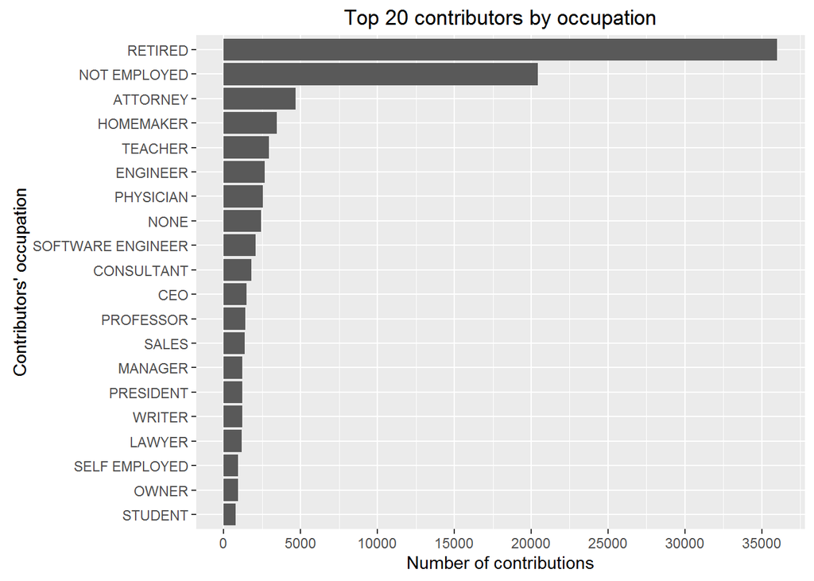

Many contributions came from the retired and the unemployed whose combined number of contributions comprised one-third of the total 180478 contributions. Attorneys, homemakers, teachers, engineers, and physicians came at distant third, fourth,… nth places. I’ll examine later what the total amount of contributions per occupation will demonstrate.

### Contributions over time

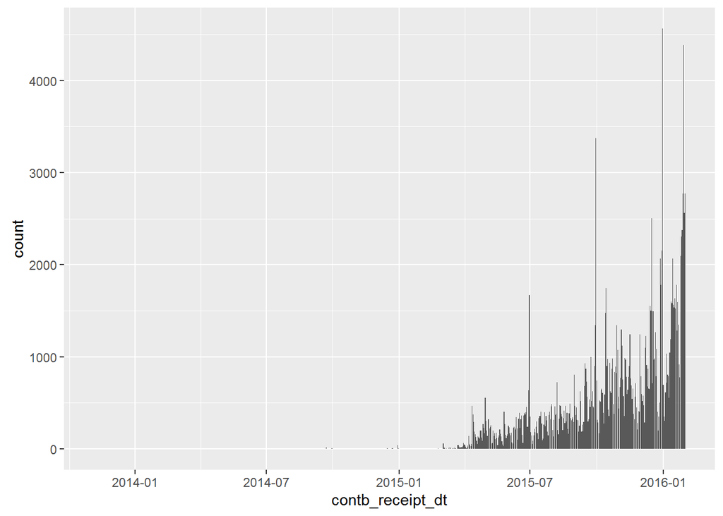

The financing activity quickly started around Mar-April 2015. The first substantial spike was around June-July 2015. Then there was an upward trend to a sudden peak around September-October of 2015. Then the density increases around December 2015 with a peak just before the new year of 2016. The increased activity continues until the last spike around the end of January.

All the spikes seem to correspond with the end of quarterly reports. There were probably financing solicitation drives near the following times March 31, June 30, September 30, and December 31 which were the dates from Presidential Campaign Finance Summaries at http://fec.gov/press/bkgnd/pres_cf/pres_cf_Even.shtml. The last spike on Jan 2016 seems to correspond with the first monthly report of the new year on Jan 31 2016.

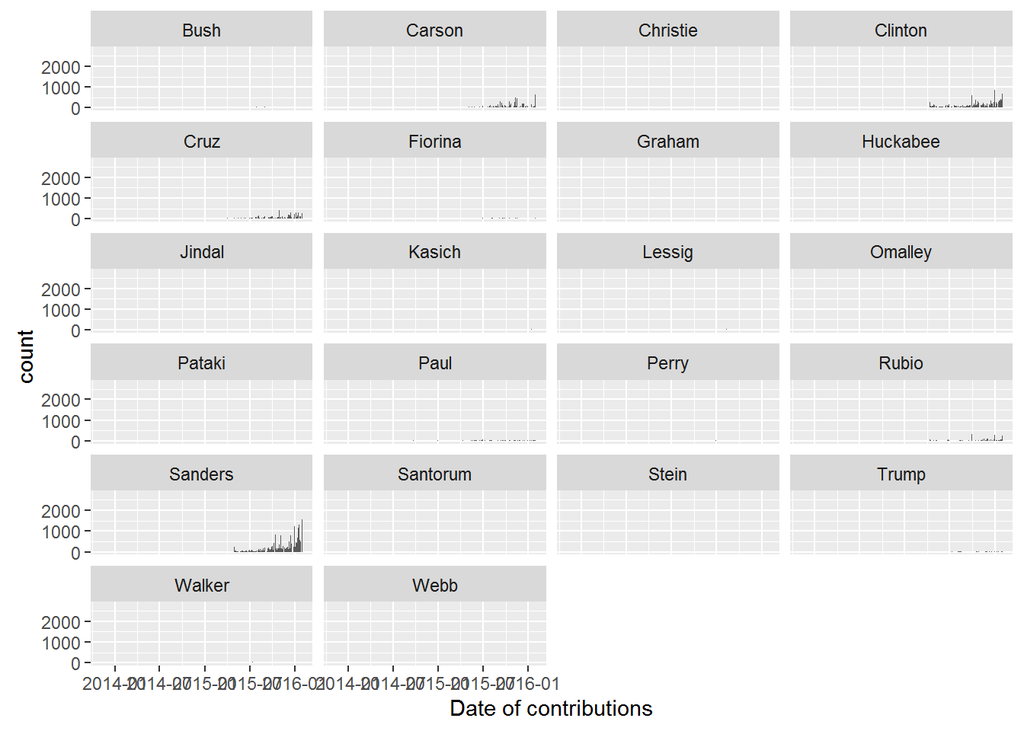

At first glance, Carson, Clinton, Cruz, and especially Sanders had a lot of financing activities. There’s some hints of activities from Bush, Christie, and Rubio.

### Top 20 cities with most number of contributions

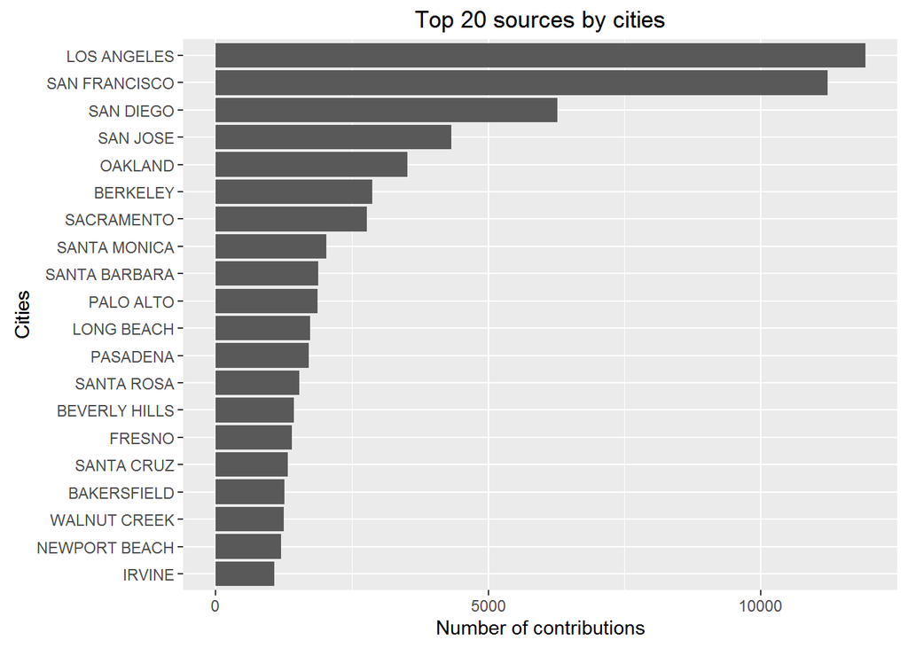

The big cities are main sources of contributions. That makes sense. I’ll examine the amounts later.

### Top 20 zip codes with most number of contributions

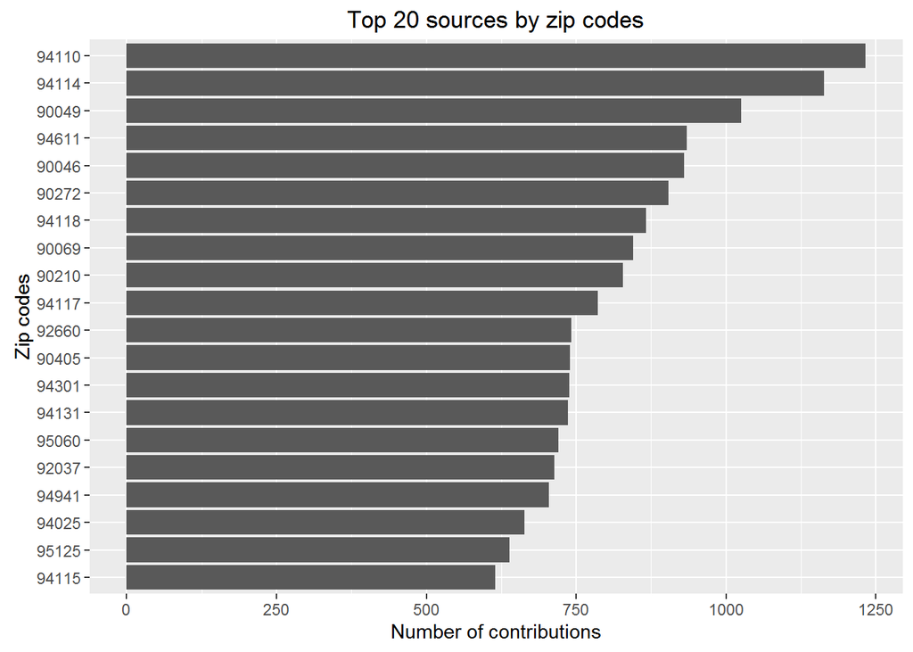

The top sources of contributions based on zip codes is not so interesting. But this is preparation for a choropleth map I plan to do based on zip codes in California. The requirements are from this site: https://rpubs.com/arilamstein/zip-vignette-1.

It is interesting to note that the top zip codes are 941xx in San Francisco; 90049, 90046, 90069 in Los Angeles; 94611 Oakland; 90272 Pacific Palisades; and the famed 90210 in Beverly Hills.

# Univariate Analysis

#### What is the structure of your dataset?

```
##  [1] "Bush"     "Carson"   "Christie" "Clinton"  "Cruz"     "Fiorina"
##  [7] "Graham"   "Huckabee" "Jindal"   "Kasich"   "Lessig"   "Omalley"
## [13] "Pataki"   "Paul"     "Perry"    "Rubio"    "Sanders"  "Santorum"
## [19] "Stein"    "Trump"    "Walker"   "Webb"
```

candidates’ party affiliations:

```
## [1] "Democrat"   "Green"      "Republican"
```

contributors’ gender

```
## [1] "female"  "male"    "unknown"
```

#### What is/are the main feature(s) of interest in your dataset?

This dataset is relatively large with 180478 observations and 23 variables. The original dataset had 18 variables. The legend of variable names are at: ftp://ftp.fec.gov/FEC/Presidential_Map/2016/DATA_DICTIONARIES/CONTRIBUTOR_FORMAT.txt.

The main features in the dataset are cand_nm (presidential candidates’ names) and contb_receipt_amt (contribution amount). The top candidates receiving contributions are Sanders and Clinton (both Democrats) while Republican Cruz and Carson are distant third and fourth.

I added gender and party affiliations which I think will be interesting to examine how they relate to each other and to other variables.

#### What other features in the dataset do you think will help support your investigation into your feature(s) of interest?

After having done the univariate analyses, I also found the contb_receipt_dt (contribution date) interesting in that one can see how the trends and peaks correspond to the frenzy of campaign activities, esp dates of filing at end of quarter and end of month.

The gender of the contributors will show the influence of the sole demographics represented in the dataset.

#### Did you create any new variables from existing variables in the dataset?

I created 2 variables, gender and cand_party (candidates’ party affiliations). I converted factor contbr_dt to date datatype. I also changed the candidates’ names, cand_nm, to just the last names. This makes plotting more readable. I also changed the zip codes from 9 characters into the first 5 characters in preparation for creating a choropleth map of California based on zip codes. It might intimate some other type of demographics perhaps economic status based on zip code.

#### Of the features you investigated, were there any unusual distributions? Did you perform any operations on the data to tidy, adjust, or change the form of the data? If so, why did you do this?

I did not notice any unusual distributions in my initial univariate analyses. As I noted earlier, the spikes in contribution activity with regards to dates corresponded to quarterly reports and monthly reports. I changed the forms of contribution dates in order to plot dates in chronological order; candidates’ names for plot readability; and the zip codes in preparation for choropleth map for later analyses.

The most time-consuming part of the preparation of the dataset is adding the gender to the contributors based on first names using the `gender` package from https://cran.r-project.org/web/packages/gender/index.html. It took more than 30 hours. Fortunately, it was mostly unattended since I automated parts of it so I can run it remotely.

My old Windows machine does not behave well with the R stastical program and R-studio. The crashes were unpredictable. It would happen while doing a simple plot or a simple table. To save myself some pain, I had to resort to saving the dataframe to an external file several times a day.

# Bivariate Plots Section

[figure not shown]

```
## [1] "Total amount contributed to all campaigns: $47,364,558"
```

```
##     cand_nm sum.contb_receipt_amt.
## 1      Bush             3333245.23
## 2    Carson             2741477.22
## 3  Christie              449491.00
## 4   Clinton            21899488.66
## 5      Cruz             3133010.53
## 6   Fiorina             1452619.42
## 7    Graham              400495.00
## 8  Huckabee              225351.60
## 9    Jindal               23231.26
## 10   Kasich              708585.37
## 11   Lessig              186144.50
## 12  Omalley              290230.16
## 13   Pataki               30450.00
## 14     Paul              814093.72
## 15    Perry              208400.00
## 16    Rubio             4562345.79
## 17  Sanders             6109590.10
## 18 Santorum               36104.88
## 19    Stein               13265.00
## 20    Trump              208891.34
## 21   Walker              461479.24
## 22     Webb               76568.16
```

```
##   cand_party sum.contb_receipt_amt.
## 1   Democrat               28562022
## 2      Green                  13265
## 3 Republican               18789272
```

**WOW!** And a special **wow** to Clinton for having raised almost nearly half of the total take of all the campaigns put together.

For zooming purposes, the boxplots below have been subset for readability. For aggregating, I did not subset since I’m assuming that the refunds will cancel the amounts that were donated.

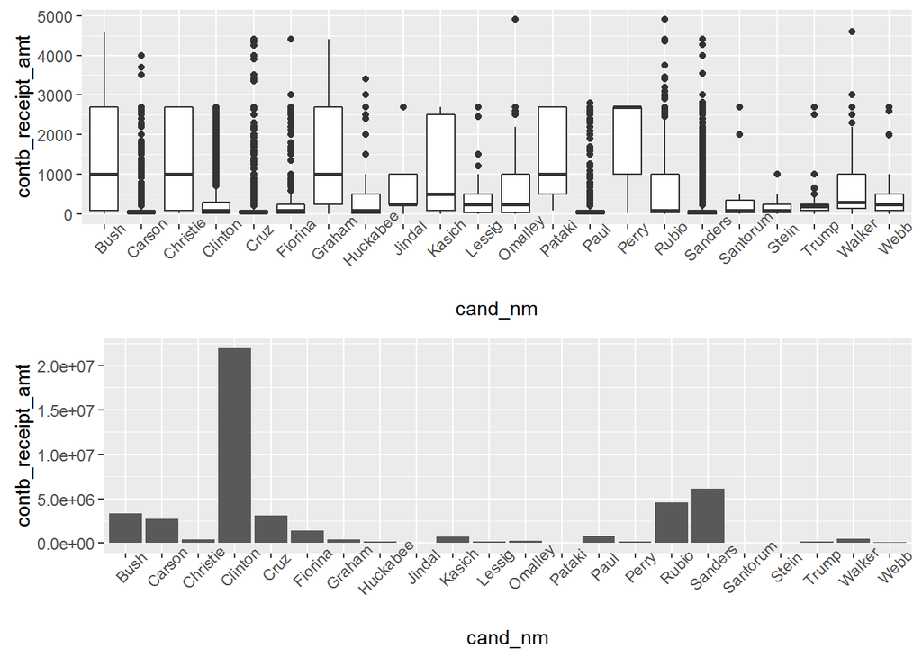

Nevertheless, small donations for both Sanders and Clinton still make up 75% of number of donations to their campaigns. The mean donations for Sanders’ and Clinton’s campaigns are below $250. It seems that Carson and Cruz who both cleared 2.5 million mark also relied on small donations.

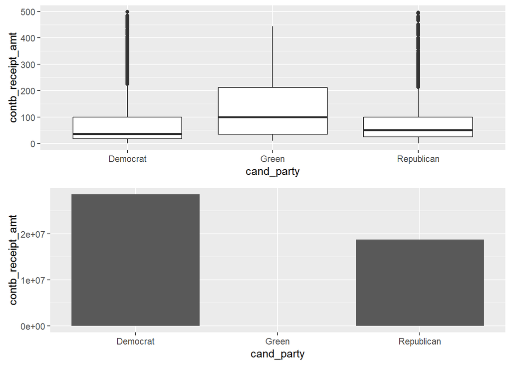

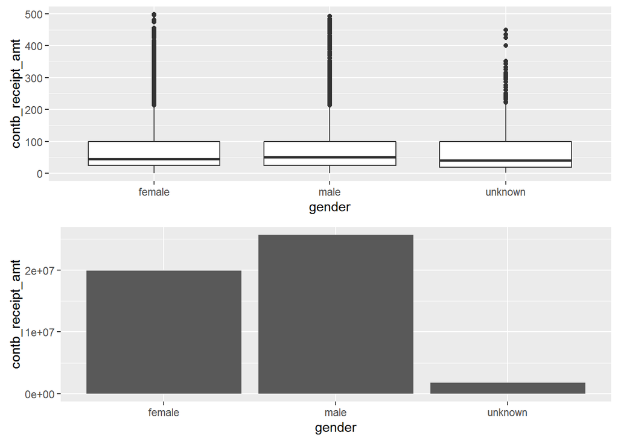

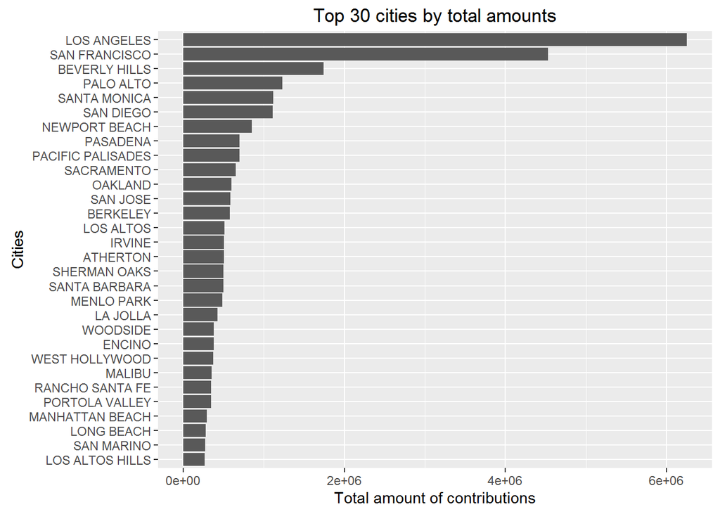

I took the top 30 cities based on total amounts contributed. I noticed that some of the top 20 contributing cities in terms of count disappeared – notably Walnut Creek, Bakersfield, Santa Cruz, Fresno, and Santa Rosa.

And some top contributing cities in terms of amount did not appear in top 20 contribution counts – notably Pacific Palisades, Los Altos, Atherton, Sherman Oaks, and nearly all the cities in the bottom of the top 30, excepting Long Beach.

This might have something to do with economic demographics in those cities. I’ll have to examine the data more closely.

### Daily contributions

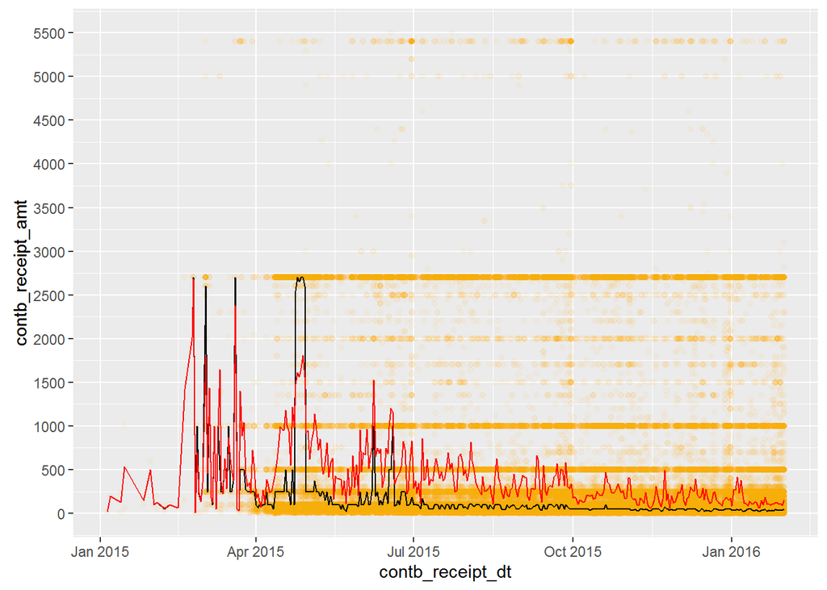

```
##    Min. 1st Qu.  Median    Mean 3rd Qu.    Max.
##    0.01   25.00   50.00  277.00  100.00 5500.00
```

```
##
##  Pearson's product-moment correlation
##
## data:  as.numeric(capcf$contb_receipt_dt) and capcf$contb_receipt_amt
## t = -103.85, df = 180480, p-value < 2.2e-16
## alternative hypothesis: true correlation is not equal to 0
## 95 percent confidence interval:
##  -0.2418010 -0.2330941
## sample estimates:
##        cor
## -0.2374523
```

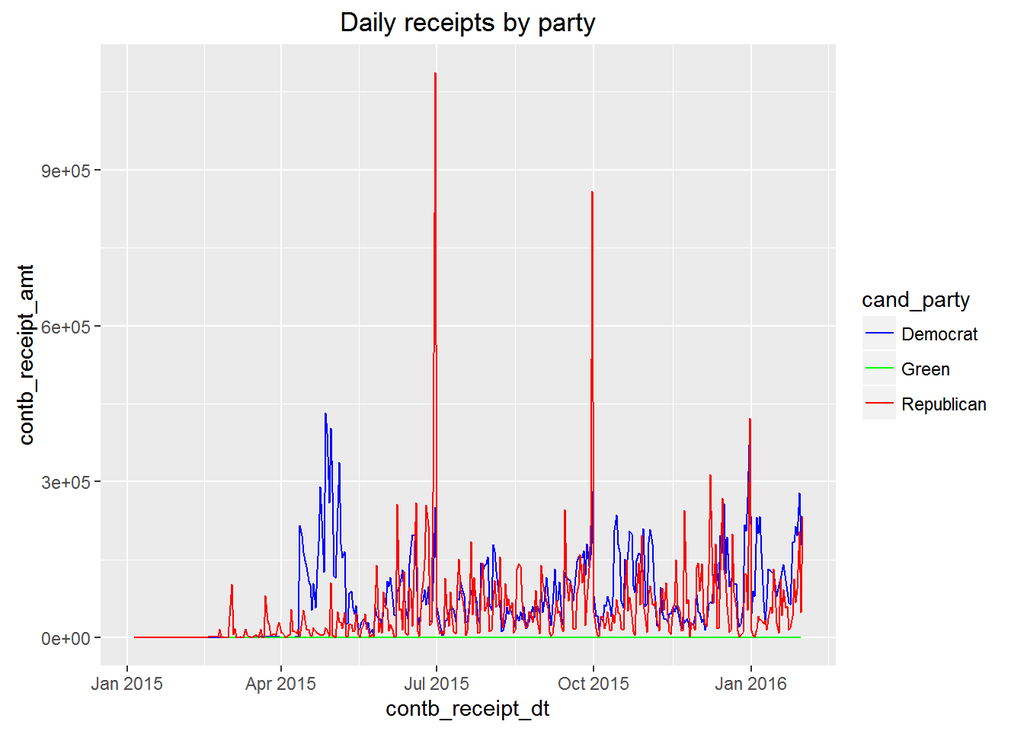

The Republicans took advantage of the quarterly reports with the spikes corresponding to the last day of filing. Which Republican(s) had busy campaign staff?

I did a correlation test between the contribution date and contribution amount. At -0.2374, there’s not much correlation other than the fact that time is progressive and events occur as time progresses.

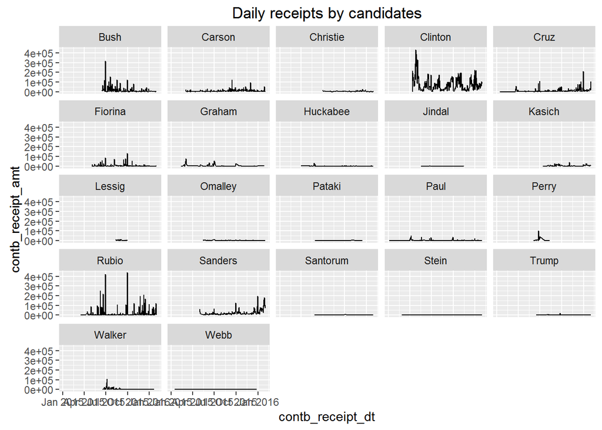

It looks like Republican Bush and Rubio had very good days at quarterly filings. But they, especially Bush, also fizzled out by the end of year. Meanwhile, Cruz had a very good end of year 2015 showing.

On the Democratic side, Sanders had a few good days before the end of the year 2015. Clinton had many good days in 2015.

The blank spaces (or lack of daily financial activity) most likely coincide with presidential campaign suspensions, like Jindal, Lessig, Pataki, and Perry. Clinton, Cruz, Rubio and Sanders kept up with the fundraising in the beginning of 2016 up the first monthly report of the year.

# Bivariate Analysis

#### Talk about some of the relationships you observed in this part of the investigation. How did the feature(s) of interest vary with other features in the dataset?

With only 2 continuous variables, namely contb_receipt_amt and contb_receipt_dt, I could only do the scatter plots against each other. I will attempt to color the scatter plots in the multivariate analysis. In fact, I used color in aesthetics to see how candidates and party affiliations relate to these continuous variables.

The campaigns with the most funding activity are also the ones which had notable spikes at end of quarter reports.

#### Did you observe any interesting relationships between the other features (not the main feature(s) of interest)?

I noticed an interesting relationship between contribution counts and total amounts raised in specific cities. Some of the top contributing cities in terms of count were missing in the top cities in terms of total amounts. I looked at some of the cities concerned. Pacific Palisades and Los Altos have demographics of upper class white residents according to https://en.wikipedia.org/wiki/List_of_California_locations_by_income, https://en.wikipedia.org/wiki/Los_Altos,_California and https://en.wikipedia.org/wiki/Pacific_Palisades,_Los_Angeles.

On the other hand, Walnut Creek and Fresno are more diverse cities in terms of economic classes and ethnic groups. I did not examine the demographics of these 2 cities but a friend did confirm that these 2 cities are primarily populated by low to middle income groups with high ethnic diversity.

#### What was the strongest relationship you found?

Other than what I have already mentioned, I am not convinced yet of the “strongest relationship”. Perhaps when I do the multivariate analyses, I might get better relationships. There could possibly be a relationship between female contributors to Clinton’s campaign. But male Sanders has attracted more females than Clinton has. The female candidate Fiorina’s fundraising activities are negligible in all counts. She’s not worth examining with this California dataset.

The demographics in cities and zip codes might also give provide more relationships against party affiliations and presidential candidates.

# Multivariate Plots Section

### Fundraising trajectory for 2016 presidential race

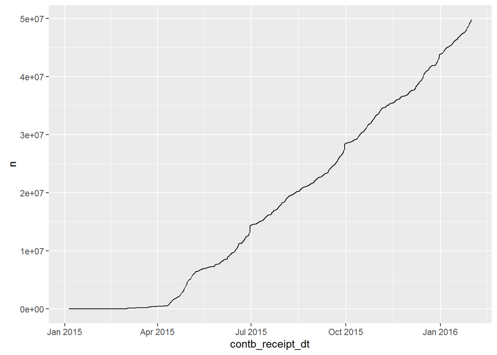

I was trying to show the cumulative amount as time progresses. I could not separate by parties. The *select* function of *dplyr* does not seem to work

## Daily receipts by party

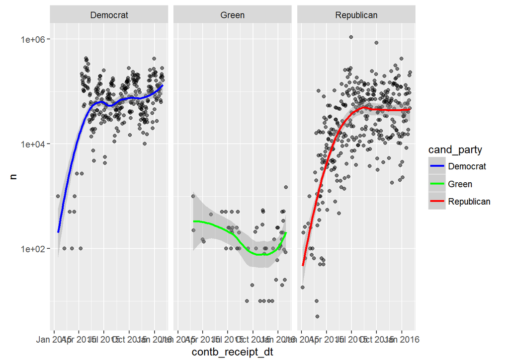

I am comparing the daily receipts by party. For scaling purposes, I scaled the y-axis logarithmically. This shows that contributions increased as the campaign progresses for both Democrats and Republicans. The Green party’s fundraising looks downward.

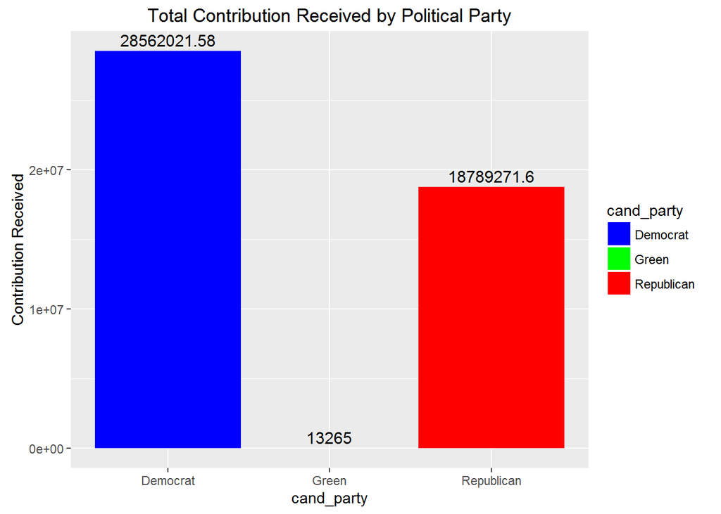

Democrats are winning the fundraising race. The Green party’s financial state is rather sad-looking, only having raised a total of $13265.

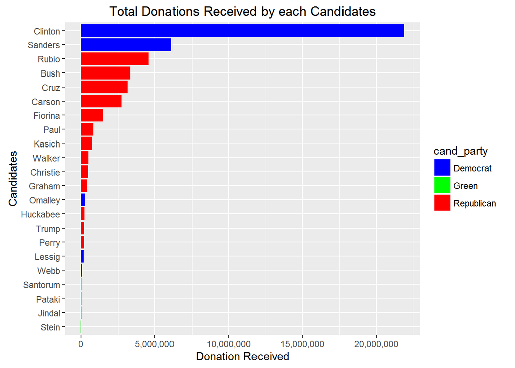

We have seen this histogram earlier. This time I added some coloring based on candidates’ party affiliations.

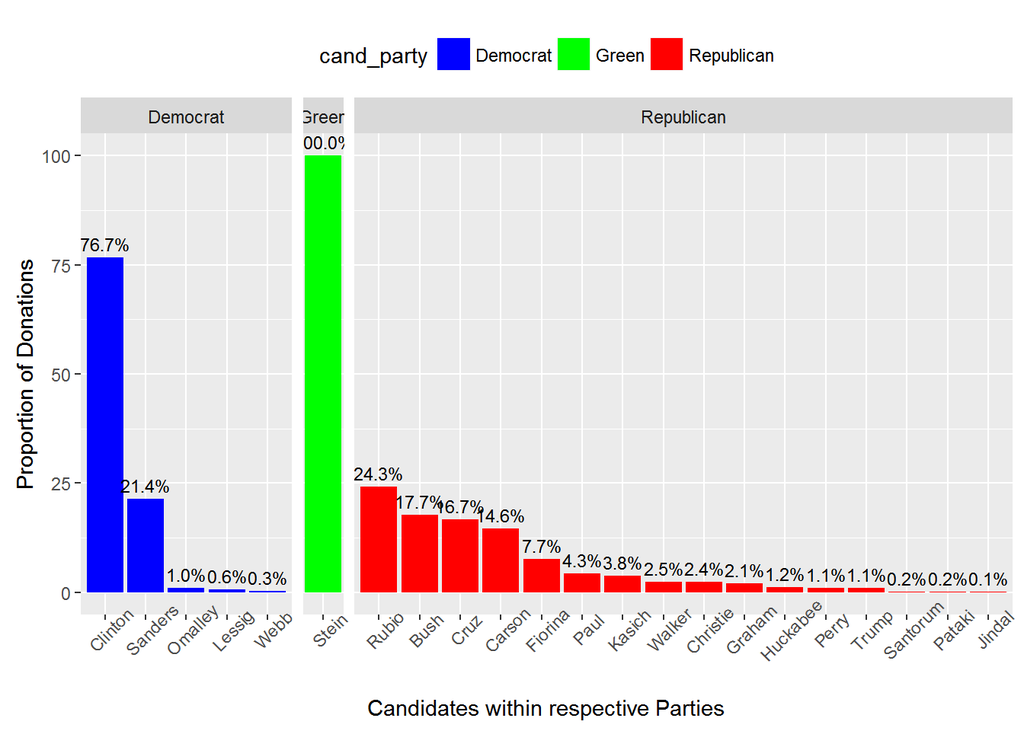

This is the one time in any of my plots that the Green party stood out. As the sole candidate, Stein clearly is the fundraising front-runner in her party.

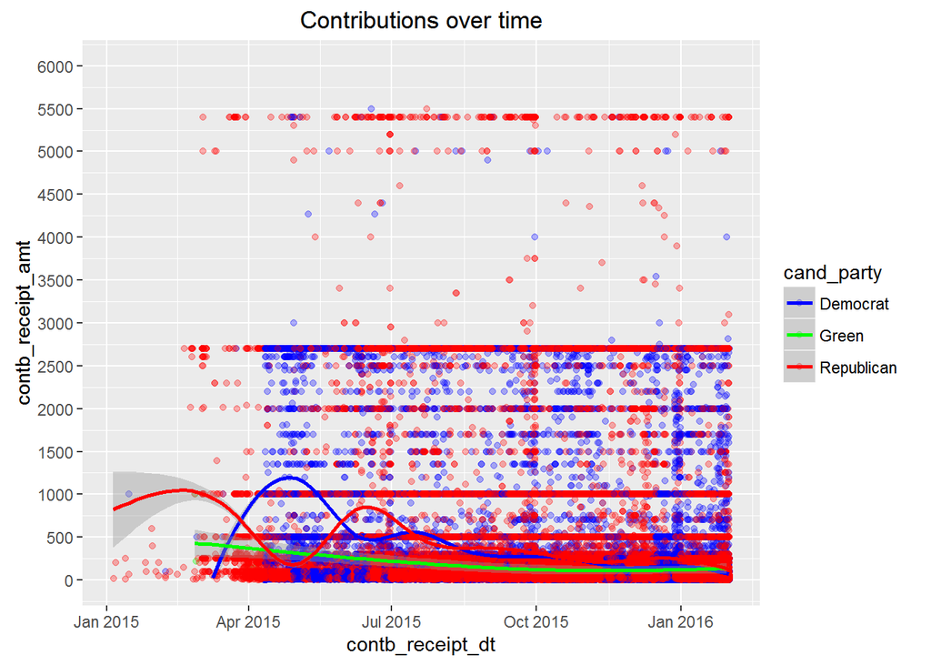

It is clear from the density of the plots that many donors contributed at 2700, 2000, 1000, 500, and 250 increments. But most donors contributed at or below 250. The smoothing lines confirm that fact. Only after the second quarterly reports were filed that activity began to stabilize.

## Attempt to create maps and plot contribution density

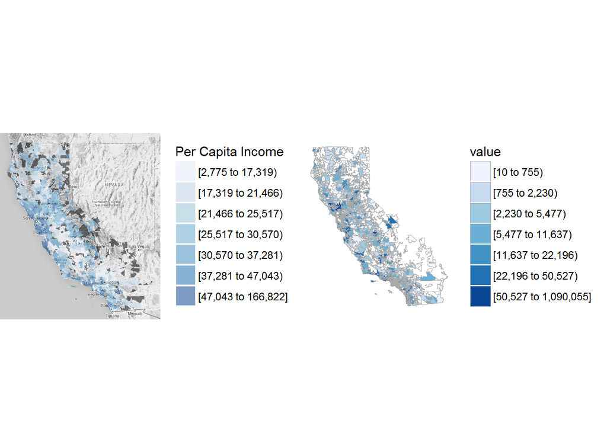

The plot on the left side is based on the census.gov data B19301 – showing the spread of income levels in California. The map on the right side shows the total amounts contributed from each zip code region.

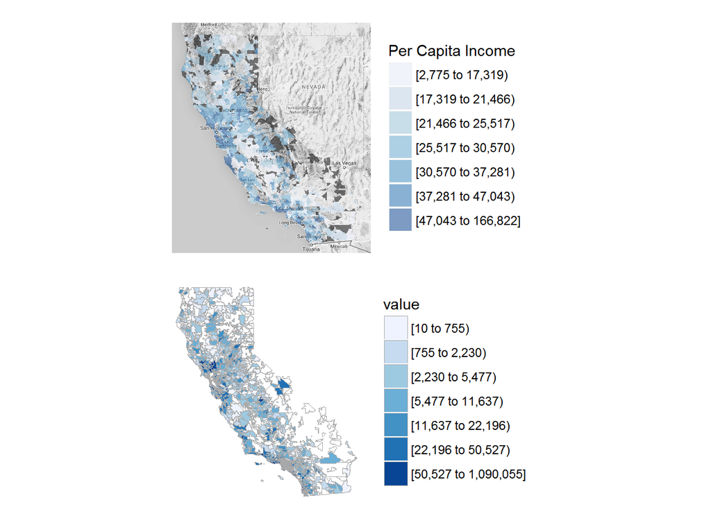

Same map as above but in one column to see more details.

I am trying to figure out what the per capita income ranges are in different zip codes in California. I thought I might be able to see a connection between income and contribution totals to campaigns.

I created the map above based on zip codes and region data from choroplethrzip. I then took the a dataset from census.gov 2013 income data from http://factfinder.census.gov/faces/affhelp/jsf/pages/metadata.xhtml?lang=en&type=table&id=table.en.ACS_13_1YR_B19301#main_content. The dataset has 2 variables, region (by zip) and value (per capita income).

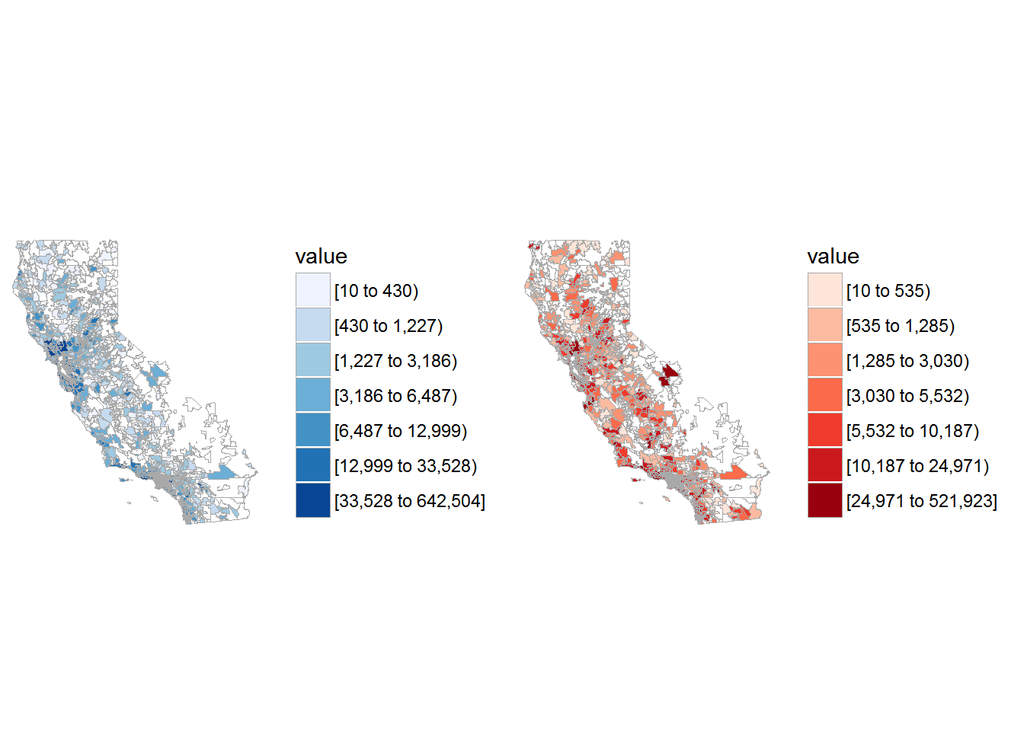

Here’s another look; But this time I separated the donations between Democrats and Republicans. It’s still not illuminating since it’s not clear exactly where the most contributions are from and to. I will try to concentrate on a smaller area of California.

### Top cities showing proportionality by party affiliations

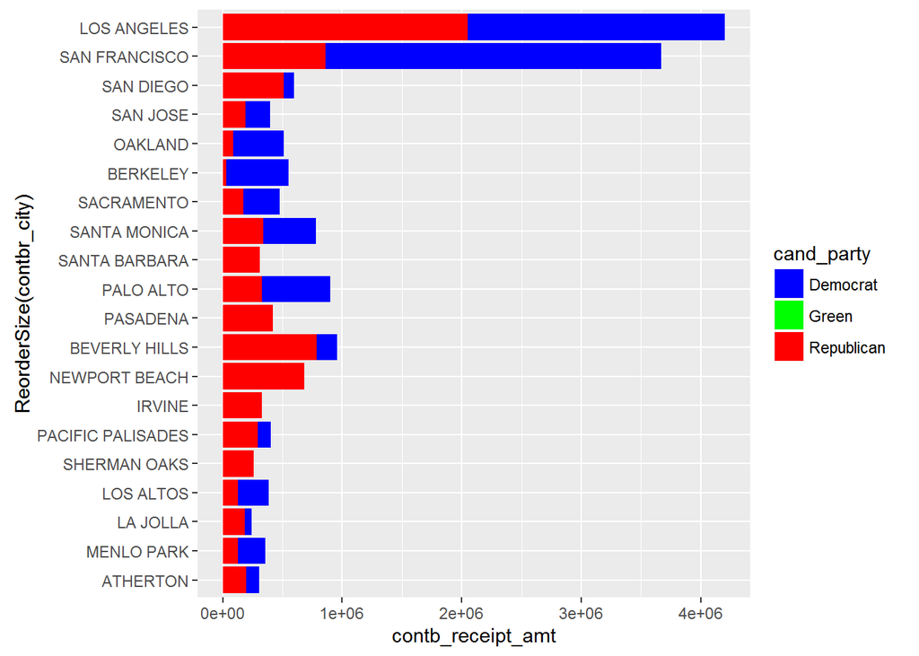

This shows the total contributions for the top 20 cities as sources of funds – colored by party affiliations. Los Angeles raised about the same amount for Democrats and Republicans, San Francisco proportionally more to Democrats as did San Jose, Oakland, Berkeley and Palo Alto. San Diego, Beverly Hills, Newport Beach, Irvine, Pacific Palisades, and La Jolla overwhelmingly leaned towards Republicans.

It is interesting that the Democratic-leaning cities are in Northern California, while the Republican-leaning cities are in Southern California.

Since Alameda county and its surrounding cities and counties are considered some of the most diverse in the nation, I will drill down in this area, specifically the San Francisco Bay Area in my last plot. See: http://www.theatlantic.com/national/archive/2014/04/mapping-racial-diversity-by-county/361388/

### Maps of counties in San Francisco Bay Area with contribution density

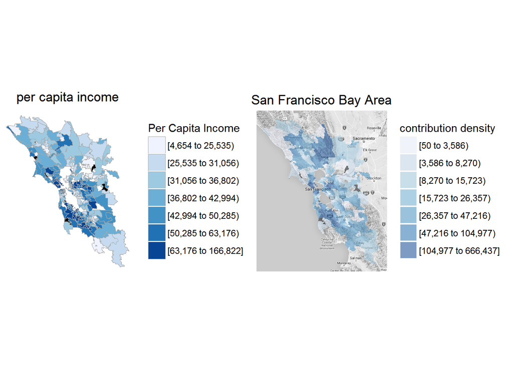

### The total amount raised in counties in the San Francisco Bay Area

```
## [1] "$16,761,842"
```